# Regression

## Dataset `trees`

```r
data(trees)
head(trees)
```

```
  Girth Height Volume
1   8.3     70   10.3
2   8.6     65   10.3
3   8.8     63   10.2
4  10.5     72   16.4
5  10.7     81   18.8
6  10.8     83   19.7
```

## Dataset `trees`; Volume vs. Girth

model: \(\text{Volume} = \beta_0 + \beta_1\cdot \text{Girth} + \varepsilon; \hspace{1cm} \varepsilon \sim \mathcal{N}(0; \sigma^2)\)  
fitted: \(\text{Volume} = \hat{\beta}_0 + \hat{\beta}_1 \cdot \text{Girth}\) \(\hat{\beta}_0 = b_0 - \text{estimate of }\beta_0\); \(\hat{\beta}_1 = b_1 - \text{estimate of }\beta_1\)

[interactive chart not shown]

## Dataset `diamond` from `UsingR`

```r
library(UsingR)
data(diamond)
head(diamond)
```

```
  carat price
1  0.17   355
2  0.16   328
3  0.17   350
4  0.18   325
5  0.25   642
6  0.16   342
```

## Dataset `diamond` from `UsingR`; Price vs. Carat

model: \(\text{Price} = \beta_0 + \beta_1\cdot \text{Carat} + \varepsilon; \hspace{1cm} \varepsilon \sim \mathcal{N}(0; \sigma^2)\)  
fitted: \(\text{Price} = \hat{\beta}_0 + \hat{\beta}_1 \cdot \text{Carat}\)

[interactive chart not shown]

```r
mod <- lm(price ~ carat, data=diamond)
summary(mod)
```

```
Call:
lm(formula = price ~ carat, data = diamond)

Residuals:
    Min      1Q  Median      3Q     Max
-85.159 -21.448  -0.869  18.972  79.370

Coefficients:
            Estimate Std. Error t value Pr(>|t|)
(Intercept)  -259.63      17.32  -14.99   <2e-16 ***
carat        3721.02      81.79   45.50   <2e-16 ***
---
Signif. codes:  0 '***' 0.001 '**' 0.01 '*' 0.05 '.' 0.1 ' ' 1

Residual standard error: 31.84 on 46 degrees of freedom
Multiple R-squared:  0.9783,    Adjusted R-squared:  0.9778
F-statistic:  2070 on 1 and 46 DF,  p-value: < 2.2e-16
```

```r
mod <- lm(price ~ carat, data=diamond)
str(mod)
```

[output not shown]

## Which line is of the best fit?

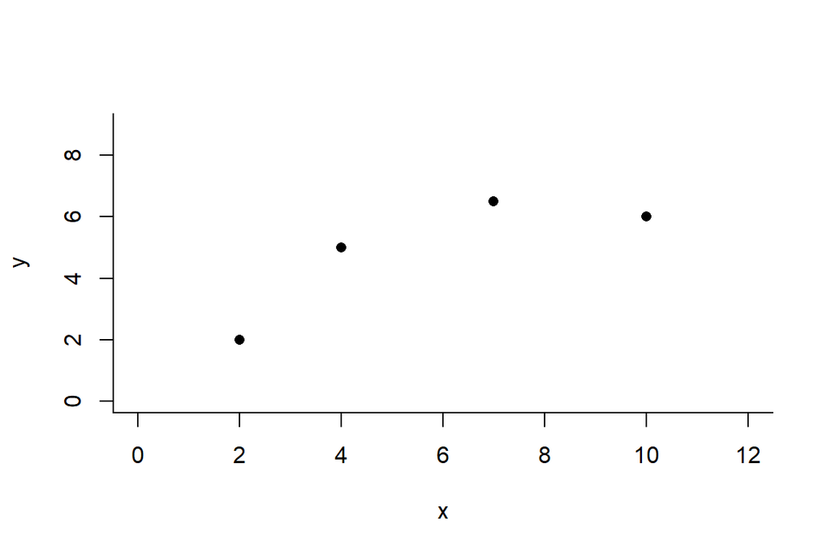

## Which line is of the best fit?

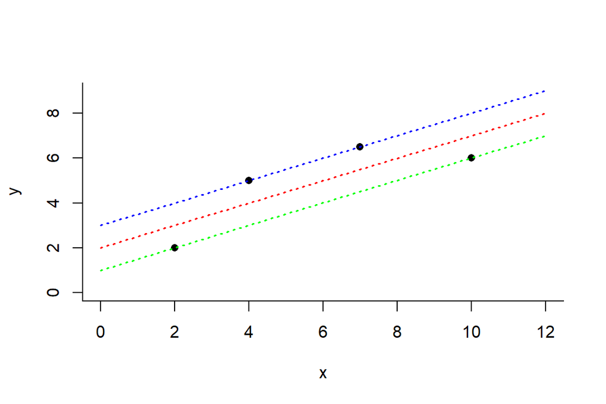

## Which line is of the best fit?

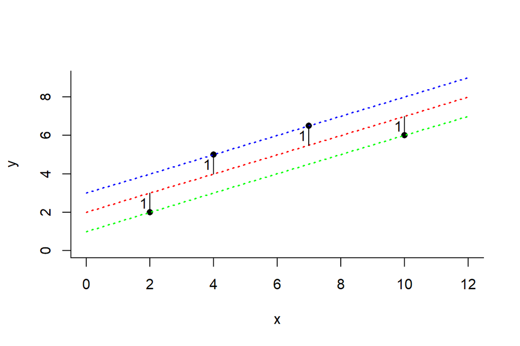

## Which line is of the best fit?

\[\begin{align} \color{blue}{L_1}: \sum |errors| &= 2 + 0 + 0 + 2 = 4 \nonumber \\ \color{red}{L_2}: \sum |errors| &= 1 + 1 + 1 + 1 = 4 \nonumber \\ \color{LightGreen}{L_3}: \sum |errors| &= 0 + 2 + 2 + 0 = 4 \end{align} \]

## Which line is of the best fit?

\[\begin{align} \color{blue}{L_1}: \sum |errors| &= 2 + 0 + 0 + 2 = 4 \nonumber \\ \color{red}{L_2}: \sum |errors| &= 1 + 1 + 1 + 1 = 4 \nonumber \\ \color{LightGreen}{L_3}: \sum |errors| &= 0 + 2 + 2 + 0 = 4 \end{align} \]

\[\begin{align} \color{blue}{L_1}: \sum |errors|^2 &= 2^2 + 0^2 + 0^2 + 2^2 = 8 \nonumber \\ \color{red}{L_2}: \sum |errors|^2 &= 1^2 + 1^2 + 1^2 + 1^2 = 4 \nonumber \\ \color{LightGreen}{L_3}: \sum |errors|^2 &= 0^2 + 2^2 + 2^2 + 0^2 = 8 \end{align} \]

## Which line is of the best fit?

\[\begin{align} \color{blue}{L_1}: \sum |errors| &= 2 + 0 + 0 + 2 = 4 \nonumber \\ \color{red}{L_2}: \sum |errors| &= 1 + 1 + 1 + 1 = 4 \nonumber \\ \color{LightGreen}{L_3}: \sum |errors| &= 0 + 2 + 2 + 0 = 4 \end{align} \]

\[\begin{align} \color{blue}{L_1}: \sum |errors|^2 &= 2^2 + 0^2 + 0^2 + 2^2 = 8 \nonumber \\ \color{red}{L_2}: \sum |errors|^2 &= 1^2 + 1^2 + 1^2 + 1^2 = 4 \nonumber \\ \color{LightGreen}{L_3}: \sum |errors|^2 &= 0^2 + 2^2 + 2^2 + 0^2 = 8 \end{align} \]

\(\vec{e} = \begin{bmatrix}e_1 \\ e_2 \\ \vdots \\ e_n\end{bmatrix} = \begin{bmatrix}y_1 - \hat{y}_1 \\ y_2-\hat{y}_2 \\ \vdots \\ y_n-\hat{y}_n \end{bmatrix}\)

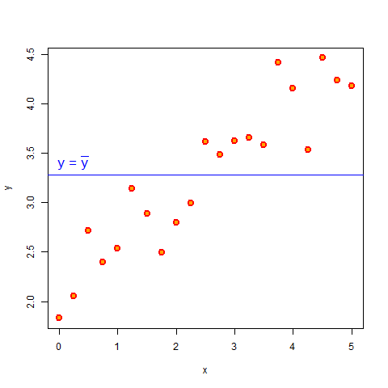

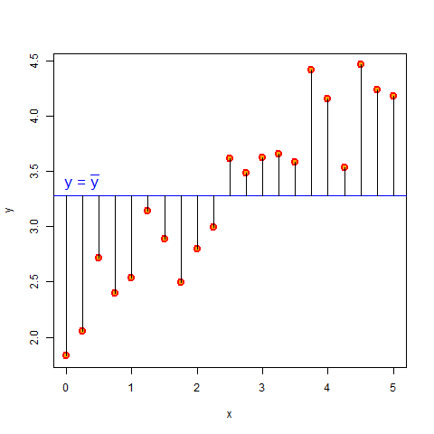

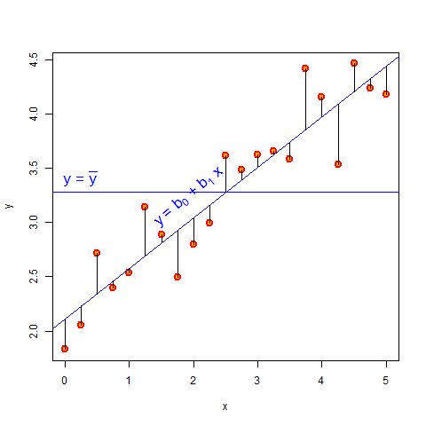

In these 3 figures we have the same data \((x_i, y_i)\), \(i=1,\dots , n\). In the 2nd figure the line segments have length \(y_i-\bar{y}\). In the 3rd figure, the line segments have length \(e_i = y_i-\hat{y}_i\). \[\sum_{i=1}^n (y_i-\bar{y})^2 = \sum_{i=1}^n (\hat{y}_i - \bar{y})^2 + \sum_{i=1}^n (y_i - \hat{y}_i)^2 \] \[(SS_y =) SST = SSM + SSE\] This relation is actually a Pythagorean Theorem in \(n\)-dimensional vector space \(\mathbf{R}^n\).

## 90% Confidence Intervals for \(\beta_0\) and \(\beta_1\)

```r
y = diamond$price; x = diamond$carat; n = length(y)

SSx = sum((x - mean(x))^2)
b1 = sum((x-mean(x)) * (y-mean(y)))/SSx;   b0 = mean(y) - b1 * mean(x)
e = y - (b0 + b1 * x)
s_sq = sum(e^2) / (n-2);  s = sqrt(s_sq)

SEb0 = sqrt(s_sq * (1 / n + mean(x) ^ 2 / SSx))
SEb1 = sqrt(s_sq / SSx)

tcrit = qt(p=0.05, df=n-2, lower.tail=FALSE)
tcrit
```

```
[1] 1.67866
```

```r
Lb0 = b0 - SEb0 * tcrit;  Rb0 = b0 + SEb0 * tcrit
Lb1 = b1 - SEb1 * tcrit;  Rb1 = b1 + SEb1 * tcrit
```

90% Confidence intervals for \(\beta_0\) and \(\beta_1\):

|  | lwr | upr |
| --- | --- | --- |
| \(\beta_0\) | -288.6983855 | -230.5534289 |
| \(\beta_1\) | 3583.7341318 | 3858.3155713 |

## 90% Confidence Intervals for \(\beta_0\) and \(\beta_1\)

The table on the previous slide was created using HTML syntax, combinded with R inline code. Here is a plain R printout.

```r
## data frame with 90% confidence intervals for b0 and b1
CI = data.frame(matrix(c(Lb0, Rb0, Lb1, Rb1), nrow=2, byrow=T),row.names=c("b0","b1"))

colnames(CI) = c("lwr","upr")   ## naming the columns of data frame CI

CI   ## printing data frame CI
```

```
         lwr       upr
b0 -288.6984 -230.5534
b1 3583.7341 3858.3156
```

Code for the `trees` dataset

```r
mod = lm(Volume ~ Girth, data=trees)
x = trees$Girth; y = trees$Volume

xax <- list(
  title = "Girth",
  titlefont = list(family="Modern Computer Roman")
)
yax <- list(
  title = "Volume",
  titlefont = list(family="Modern Computer Roman"),
  range = c(0,80)
)

fig <- plot_ly(x=x, y=y, type="scatter", mode="markers", name="data",
        width=800, height=430) %>%
        add_lines(x = x, y = fitted(mod), name="fitted") %>%
        layout(xaxis = xax, yaxis = yax) %>%
        layout(margin=list(
            l=150,
            r=50,
            b=20,
            t=40
            )
        )
config(fig, displaylogo=FALSE)
```

[interactive chart not shown]

## `mpg` VS. `wt` from dataset `mtcars`; `color=disp`

```r
data(mtcars)
attach(mtcars)
head(mtcars)
```

```
                   mpg cyl disp  hp drat    wt  qsec vs am gear carb
Mazda RX4         21.0   6  160 110 3.90 2.620 16.46  0  1    4    4
Mazda RX4 Wag     21.0   6  160 110 3.90 2.875 17.02  0  1    4    4
Datsun 710        22.8   4  108  93 3.85 2.320 18.61  1  1    4    1
Hornet 4 Drive    21.4   6  258 110 3.08 3.215 19.44  1  0    3    1
Hornet Sportabout 18.7   8  360 175 3.15 3.440 17.02  0  0    3    2
Valiant           18.1   6  225 105 2.76 3.460 20.22  1  0    3    1
```

```r
xax <- list(
  title = "Weight",
  titlefont = list(family="Modern Computer Roman")
)

yax <- list(
  title = "Miles per Gallon",
  titlefont = list(family="Modern Computer Roman")
)

plot_ly(mtcars, x=wt, y=mpg, type="scatter", mode="markers", color=disp) %>%
  layout(xaxis= xax, yaxis=yax)
```

[interactive chart not shown]

## `mpg` VS. `wt` from dataset `mtcars`

color = # cylinders; size = hp

```r
data(mtcars); attach(mtcars)
plot_ly(mtcars, x=wt, y=mpg, mode="markers",
        color=as.factor(cyl), size=hp,
        width=600, height=350) %>%
  layout(xaxis= xax, yaxis=yax)
```

[interactive chart not shown]